# nb2_enc+scal+fs_final

3. Imports and uploads  
   3.1. Libraries  
   3.2. Datasets
4. Data preparation  
   4.1. Numerical/categorical data partition  
   4.2. Encoding - Categorical Data  
   4.1.1. Evaluation of best technique  
   4.1.2. Applying encoding techniques
5. Target Balancing
6. Data Scaling
7. Feature Selection  
   7.1. Filter Methods  
   7.1.1. Variance  
   7.1.2. Correlation Indices  
   7.1.2.1. Between input variables - Redundancy  
   7.1.2.2. Between output variable - Relevancy  
   7.1.3. ANOVA  
   7.2. Wrapper Methods  
   7.2.1. RFE - Base Model: Logistic Regression Classifier  
   7.2.2. RFE - Base Model: Support Vector Machines  
   7.3. Embedded Methods  
   7.3.1. Lasso  
   7.3.2. Random Forest Classifier  
   7.4. Standalone Methods  
   7.4.1. Decision Trees
8. Final Insights  
   8.1. Final feature selection  
   8.2. Export Datasets and variables for following notebook

## 3. Imports and uploads

### 3.1. Libraries

```python
import pandas as pd
import numpy as np
import matplotlib.pyplot as plt
import seaborn as sns
import category_encoders as ce
from sklearn.preprocessing import MinMaxScaler
import joblib
from sklearn.model_selection import train_test_split

# SVM
from sklearn.svm import SVC

# Logistic Regression
from sklearn.linear_model import LogisticRegression
from sklearn.feature_selection import RFE

# ANOVA
from sklearn.feature_selection import SelectKBest
from sklearn.feature_selection import f_classif

# Random Forest
from sklearn.ensemble import RandomForestClassifier
from sklearn.feature_selection import SelectFromModel

# Decision Tree
from sklearn.tree import DecisionTreeClassifier

# SMOTE, undersampling
from imblearn.over_sampling import SMOTE
from imblearn.under_sampling import RandomUnderSampler
from collections import Counter

# LASSO
from sklearn.linear_model import LassoCV

import warnings
warnings.filterwarnings('ignore')
%config InlineBackend.figure_format = 'retina'
sns.set()
```

### 3.2. Datasets

```python
X_train = pd.read_csv('X_train_nb1.csv', index_col=0)
X_val = pd.read_csv('X_val_nb1.csv', index_col=0)
X_test = pd.read_csv('X_test_nb1.csv', index_col=0)
```

```python
y_train = pd.read_csv("y_train_nb1.csv", index_col=0)
y_val = pd.read_csv("y_val.csv", index_col=0)
```

```python
y_train = y_train.iloc[:, 0]
y_val = y_val.iloc[:, 0]
```

## 4. Data Preparation

## 4.1 Numerical/categorical data partition

**`Preparing Data for partition`**

`Step 1` Confirm there are no missing values

```python
(X_test.isna().sum() == 0) & (X_train.isna().sum() == 0) & (X_val.isna().sum() == 0)
```

```
Age at Injury                     True
Alternative Dispute Resolution    True
Attorney/Representative           True
Average Weekly Wage               True
Birth Year                        True
Carrier Name                      True
Carrier Type                      True
Claim Identifier                  True
County of Injury                  True
COVID-19 Indicator                True
District Name                     True
Gender                            True
IME-4 Count                       True
Industry Code                     True
Medical Fee Region                True
WCIO Cause of Injury Code         True
WCIO Nature of Injury Code        True
WCIO Part Of Body Code            True
Zip Code                          True
First Hearing                     True
C-3 Delivery                      True
Days from Accident to C-2         True
Days from Accident to Assembly    True
Log_Average_Weekly_Wage           True
Age_Group                         True
Claim Antiguity                   True
C-2 under Deadline                True
Forms Delivered Count             True
Valid Full Claim                  True
Injury Group                      True
Body Part Group                   True
Nature of Injury Group            True
Industry Group                    True
Accident Year                     True
Accident Month                    True
Assembly Year                     True
Assembly Month                    True
C-2 Year                          True
C-2 Month                         True
dtype: bool
```

`Step 2` Confirm that X and y have the same size in rows and that they are aligned, in each dataset

```python
y_train.shape[0] == X_train.shape[0]
```

```
True
```

```python
y_val.shape[0] == X_val.shape[0]
```

```
True
```

```python
# Check if indices are aligned
print((X_train.index == y_train.index).all())
```

```
True
```

```python
# Check if indices are aligned
print((X_val.index == y_val.index).all())
```

```
True
```

`Step 3` As we import datsets, some features change dtypes - doublecheck and update datatypes, to appropriately distinguish numerical features from categorical

```python
X_train.info()
```

```
<class 'pandas.core.frame.DataFrame'>
Index: 401818 entries, 65312 to 133536
Data columns (total 39 columns):
 #   Column                          Non-Null Count   Dtype
---  ------                          --------------   -----
 0   Age at Injury                   401818 non-null  int64
 1   Alternative Dispute Resolution  401818 non-null  int64
 2   Attorney/Representative         401818 non-null  int64
 3   Average Weekly Wage             401818 non-null  float64
 4   Birth Year                      401818 non-null  int64
 5   Carrier Name                    401818 non-null  object
 6   Carrier Type                    401818 non-null  int64
 7   Claim Identifier                401818 non-null  int64
 8   County of Injury                401818 non-null  object
 9   COVID-19 Indicator              401818 non-null  int64
```

[output cut: 31 more lines]

```python
# List of features to convert to object
object_columns = [
    'Medical Fee Region',
    'Carrier Type','Zip Code',
    'Industry Code', 'WCIO Cause of Injury Code', 'WCIO Nature of Injury Code',
    'WCIO Part Of Body Code']
```

```python
# Convert features to object type in X_train, X_val, and X_test
for dataset in [X_train, X_val, X_test]:
    dataset[object_columns] = dataset[object_columns].astype('object')
```

```python
X_train.info()
```

```
<class 'pandas.core.frame.DataFrame'>
Index: 401818 entries, 65312 to 133536
Data columns (total 39 columns):
 #   Column                          Non-Null Count   Dtype
---  ------                          --------------   -----
 0   Age at Injury                   401818 non-null  int64
 1   Alternative Dispute Resolution  401818 non-null  int64
 2   Attorney/Representative         401818 non-null  int64
 3   Average Weekly Wage             401818 non-null  float64
 4   Birth Year                      401818 non-null  int64
 5   Carrier Name                    401818 non-null  object
 6   Carrier Type                    401818 non-null  object
 7   Claim Identifier                401818 non-null  int64
 8   County of Injury                401818 non-null  object
 9   COVID-19 Indicator              401818 non-null  int64
```

[output cut: 31 more lines]

**`Define numerical and categorical data`**

```python
# NUM
X_train_num = X_train.select_dtypes(include=['number'])
X_train_num = X_train_num.drop('Claim Identifier', axis=1, errors='ignore')
# Drop 'Claim Identifier' - we do not include claim identifier, since it is not a meaningful feature, just an id

#CAT
X_train_cat = X_train.select_dtypes(exclude=np.number)
```

```python
# Same for validation
X_val_num = X_val.select_dtypes(include=['number'])
X_val_num = X_val_num.drop('Claim Identifier', axis=1, errors='ignore')

X_val_cat = X_val.select_dtypes(exclude=np.number)

#And test
X_test_num = X_test.select_dtypes(include=['number'])
X_test_num = X_test_num.drop('Claim Identifier', axis=1, errors='ignore')

X_test_cat = X_test.select_dtypes(exclude=np.number)
```

```python
# Check if indices are aligned
print((X_train_num.index == X_train_cat.index).all())
```

```
True
```

`Step 4` Confirm that categorical and numerical data have the same size in columns for all datasets

```python
X_train_num.shape[1] == X_val_num.shape[1] == X_test_num.shape[1]
```

```
True
```

```python
X_train_cat.shape[1] == X_val_cat.shape[1] == X_test_cat.shape[1]
```

```
True
```

## 4.2. Encoding - Categorical Data

### 4.2.1. Evaluation of best technique

The encoders we decide to use must be suitable for our dataset, and the most important factors to decide which method is the best includes:

- count of unique values
- ordinality nature of feature
- whether features have a fixed and finite count of unique categories or not

`Count of unique values`

```python
X_train_cat.columns
```

```
Index(['Carrier Name', 'Carrier Type', 'County of Injury', 'District Name',
       'Industry Code', 'Medical Fee Region', 'WCIO Cause of Injury Code',
       'WCIO Nature of Injury Code', 'WCIO Part Of Body Code', 'Zip Code',
       'Age_Group', 'Injury Group', 'Body Part Group',
       'Nature of Injury Group', 'Industry Group'],
      dtype='object')
```

```python
X_train_cat.nunique()
```

```
Carrier Name                  1969
Carrier Type                     5
County of Injury                62
District Name                    8
Industry Code                   20
Medical Fee Region               4
WCIO Cause of Injury Code       74
WCIO Nature of Injury Code      56
WCIO Part Of Body Code          54
Zip Code                      6991
Age_Group                        6
Injury Group                    13
Body Part Group                  8
Nature of Injury Group           7
Industry Group                   9
dtype: int64
```

`Inspecting unique values`

```python
X_train_cat.apply(lambda x: x.unique(), axis=0)
```

```
Carrier Name                  [STATE INSURANCE FUND, SIRIUSPOINT AMERICA INS...
Carrier Type                                                    [2, 1, 3, 4, 5]
County of Injury              [CAYUGA, QUEENS, MONROE, ALBANY, KINGS, WESTCH...
District Name                 [SYRACUSE, NYC, ROCHESTER, ALBANY, BINGHAMTON,...
Industry Code                 [11.0, 31.0, 62.0, 22.0, 52.0, 92.0, 53.0, 44....
Medical Fee Region                                                 [1, 4, 3, 2]
WCIO Cause of Injury Code     [53.0, 31.0, 56.0, 32.0, 29.0, 83.0, 74.0, 60....
WCIO Nature of Injury Code    [52.0, 10.0, 49.0, 90.0, 83.0, 59.0, 4.0, 16.0...
WCIO Part Of Body Code        [55.0, 65.0, 38.0, 32.0, 90.0, 60.0, 56.0, 10....
Zip Code                      [13143, 11368, 14580, 12065, 11203, 10550, 136...
Age_Group                     [Young Adults, Middle Adults, Mature Adults, T...
Injury Group                  [Repetitive Motion, Falls and Slips, Lifting o...
Body Part Group               [Lower Extremities, Other, Upper Extremities, ...
Nature of Injury Group        [Physical Injuries, Infection and Diseases, Ot...
Industry Group                [Agriculture & Environment, Manufacturing, Hea...
dtype: object
```

`Features with unique values on val/test not seen on train dataset`

```python
mismatched_features = []

# Loop through each feature in X_train columns to check if its the same size as val/test
for feature in X_train.select_dtypes(include='object').columns:
    train_unique = set(X_train[feature].unique())
    test_unique = set(X_test[feature].unique())

    if train_unique != test_unique:
        # Find unique values in X_test that are not in X_train
        unique_in_test_not_train = test_unique - train_unique
        mismatched_features.append((feature, len(unique_in_test_not_train)))  # Store the count of unique values

# Print features where the unique values differ and how many unique values are not in train
if mismatched_features:
    print("Features with mismatched unique values between X_train and X_test:")
    for feature, unique_count in mismatched_features:
        print(f"- {feature}: {unique_count} unique values in X_test not in X_train")
else:
    print("No mismatched unique values between X_train and X_test.")
#improve code, to only include features with uniques that dont appear on train
```

```
Features with mismatched unique values between X_train and X_test:
- Carrier Name: 102 unique values in X_test not in X_train
- WCIO Part Of Body Code: 0 unique values in X_test not in X_train
- Zip Code: 2025 unique values in X_test not in X_train
- Body Part Group: 1 unique values in X_test not in X_train
```

### 4.2.2. Applying encoding techniques

`Count Encoding` Counts the number of ocurrences in each unique value and replace with count values- Useful for high number of unique values.

Considerations:

- After this encoding, the features becomes numerical
- By default, CountEncoder will assign a count of 0 to any category in X_test/X_val that was not present in X_train.

```python
count_encoder = ce.CountEncoder()
```

```python
X_train_cat.info()
```

```
<class 'pandas.core.frame.DataFrame'>
Index: 401818 entries, 65312 to 133536
Data columns (total 15 columns):
 #   Column                      Non-Null Count   Dtype
---  ------                      --------------   -----
 0   Carrier Name                401818 non-null  object
 1   Carrier Type                401818 non-null  object
 2   County of Injury            401818 non-null  object
 3   District Name               401818 non-null  object
 4   Industry Code               401818 non-null  object
 5   Medical Fee Region          401818 non-null  object
 6   WCIO Cause of Injury Code   401818 non-null  object
 7   WCIO Nature of Injury Code  401818 non-null  object
 8   WCIO Part Of Body Code      401818 non-null  object
 9   Zip Code                    401818 non-null  object
 10  Age_Group                   401818 non-null  object
 11  Injury Group                401818 non-null  object
 12  Body Part Group             401818 non-null  object
 13  Nature of Injury Group      401818 non-null  object
 14  Industry Group              401818 non-null  object
dtypes: object(15)
memory usage: 49.1+ MB
```

```python
count_encode = ['Carrier Name', 'Carrier Type', 'County of Injury',
       'District Name', 'Industry Code', 'Medical Fee Region',
       'WCIO Cause of Injury Code', 'WCIO Nature of Injury Code',
       'WCIO Part Of Body Code', 'Zip Code', 'Age_Group',
       'Injury Group', 'Body Part Group', 'Nature of Injury Group',
       'Industry Group']
```

```python
# Apply count encoding on specific columns using the CountEncoder
X_train_encoded = count_encoder.fit_transform(X_train_cat[count_encode])
joblib.dump(count_encoder, 'encoder.pkl')
```

```
['encoder.pkl']
```

```python
X_val_encoded = count_encoder.transform(X_val_cat[count_encode])
X_test_encoded = count_encoder.transform(X_test_cat[count_encode])
```

**The count of categories in test dataset that weren't on train, now codified as 0:**

```python
(X_test_encoded == 0).sum()
#The count of categories that weren't on train, so were codified as 0
```

```
Carrier Name                  1200
Carrier Type                     0
County of Injury                 0
District Name                    0
Industry Code                    0
Medical Fee Region               0
WCIO Cause of Injury Code        0
WCIO Nature of Injury Code       0
WCIO Part Of Body Code           0
Zip Code                      2836
Age_Group                        0
Injury Group                     0
Body Part Group                577
Nature of Injury Group           0
Industry Group                   0
dtype: int64
```

**Updating each datasets numerical partition with columns encoded into numerical feature:**

```python
X_train_num[count_encode] = X_train_encoded
X_val_num[count_encode] = X_val_encoded
X_test_num[count_encode] = X_test_encoded
#Updating columns in X_train_num with their correct encoded version
```

```python
X_train_num.head(1)
```

|  | Age at Injury | Alternative Dispute Resolution | Attorney/Representative | Average Weekly Wage | Birth Year | COVID-19 Indicator | Gender | IME-4 Count | First Hearing | C-3 Delivery | ... | Medical Fee Region | WCIO Cause of Injury Code | WCIO Nature of Injury Code | WCIO Part Of Body Code | Zip Code | Age_Group | Injury Group | Body Part Group | Nature of Injury Group | Industry Group |
| --- | --- | --- | --- | --- | --- | --- | --- | --- | --- | --- | --- | --- | --- | --- | --- | --- | --- | --- | --- | --- | --- |
| 65312 | 23 | 0 | 0 | 756.52 | 1996 | 0 | 1 | 0 | 0 | 0 | ... | 94851 | 8335 | 118347 | 17460 | 63 | 76965 | 39138 | 95183 | 331907 | 2157 |

1 rows × 38 columns

**Removing from categorical partition columns encoded into numerical features:**

```python
X_train_cat = X_train_cat.drop(columns=count_encode)
X_val_cat = X_val_cat.drop(columns=count_encode)
X_test_cat = X_test_cat.drop(columns=count_encode)
```

After using count encoding, the encoded features become numerical.  
**Doublechecking they all features encoded with frequency/count are numerical, and the same across datasets:**

```python
(X_train_num[count_encode].select_dtypes(include='number').columns.isin(count_encode).all() &
    X_val_num[count_encode].select_dtypes(include='number').columns.isin(count_encode).all() &
    X_test_num[count_encode].select_dtypes(include='number').columns.isin(count_encode).all())
#This code checks whether the all columns in count_encode are numerical
```

```
True
```

```python
X_train_num.columns == X_test_num.columns
```

```
array([ True,  True,  True,  True,  True,  True,  True,  True,  True,
        True,  True,  True,  True,  True,  True,  True,  True,  True,
        True,  True,  True,  True,  True,  True,  True,  True,  True,
        True,  True,  True,  True,  True,  True,  True,  True,  True,
        True,  True])
```

## 5. Target Class Balancing

We will apply hybrid resampling by undersampling majority classes and oversampling minority classes using SMOTE. This balances the dataset, improving the model’s ability to learn from all classes and enhancing performance on underrepresented ones.

```python
target = 'Claim Injury Type'

# Apply undersampling for majority classes
undersampler = RandomUnderSampler(sampling_strategy={
    2: 100000,  # Reduce class 2 to 100,000 samples
    4: 50000    # Reduce class 4 to 50,000 samples
}, random_state=42)

X_train_under, y_train_under = undersampler.fit_resample(X_train_num, y_train)

# Apply SMOTE for extreme minority classes
smote = SMOTE(sampling_strategy={
    1: 20000,
    7: 10000,
    8: 10000,
    6: 20000
}, random_state=42)

X_resampled, y_resampled = smote.fit_resample(X_train_under, y_train_under)

print("Class distribution before resampling:", Counter(y_train))
print("Class distribution after resampling:", Counter(y_resampled))

# Confirm resampled data
X_resampled_df = pd.DataFrame(X_resampled, columns=X_train_num.columns)
y_resampled_df = pd.Series(y_resampled, name=target)
```

```
Class distribution before resampling: Counter({2: 203754, 4: 103955, 3: 48234, 5: 33796, 1: 8734, 6: 2948, 8: 329, 7: 68})
Class distribution after resampling: Counter({2: 100000, 4: 50000, 3: 48234, 5: 33796, 1: 20000, 6: 20000, 7: 10000, 8: 10000})
```

```python
X_resampled_df.columns
```

```
Index(['Age at Injury', 'Alternative Dispute Resolution',
       'Attorney/Representative', 'Average Weekly Wage', 'Birth Year',
       'COVID-19 Indicator', 'Gender', 'IME-4 Count', 'First Hearing',
       'C-3 Delivery', 'Days from Accident to C-2',
       'Days from Accident to Assembly', 'Log_Average_Weekly_Wage',
       'Claim Antiguity', 'C-2 under Deadline', 'Forms Delivered Count',
       'Valid Full Claim', 'Accident Year', 'Accident Month', 'Assembly Year',
       'Assembly Month', 'C-2 Year', 'C-2 Month', 'Carrier Name',
       'Carrier Type', 'County of Injury', 'District Name', 'Industry Code',
       'Medical Fee Region', 'WCIO Cause of Injury Code',
       'WCIO Nature of Injury Code', 'WCIO Part Of Body Code', 'Zip Code',
       'Age_Group', 'Injury Group', 'Body Part Group',
       'Nature of Injury Group', 'Industry Group'],
      dtype='object')
```

`Step 1` Confirming that there is no null values on resampled dataset

```python
X_resampled_df.isna().sum()
```

```
Age at Injury                     0
Alternative Dispute Resolution    0
Attorney/Representative           0
Average Weekly Wage               0
Birth Year                        0
COVID-19 Indicator                0
Gender                            0
IME-4 Count                       0
First Hearing                     0
C-3 Delivery                      0
Days from Accident to C-2         0
Days from Accident to Assembly    0
Log_Average_Weekly_Wage           0
Claim Antiguity                   0
C-2 under Deadline                0
Forms Delivered Count             0
Valid Full Claim                  0
Accident Year                     0
Accident Month                    0
Assembly Year                     0
Assembly Month                    0
C-2 Year                          0
C-2 Month                         0
Carrier Name                      0
Carrier Type                      0
County of Injury                  0
District Name                     0
Industry Code                     0
Medical Fee Region                0
WCIO Cause of Injury Code         0
WCIO Nature of Injury Code        0
WCIO Part Of Body Code            0
Zip Code                          0
Age_Group                         0
Injury Group                      0
Body Part Group                   0
Nature of Injury Group            0
Industry Group                    0
dtype: int64
```

## 6. Data Scaling

We use a Normalization scaler, knowing the following assumptions:

- it is sensitive to outliers - but we treated most of them
- doesn't assume data is normally distributed - because in our case it isn't

```python
scaler = MinMaxScaler(feature_range=(0, 1))

#fit to training data
X_train_num_scaled = scaler.fit_transform(X_resampled_df)
joblib.dump(scaler, 'scaler.pkl')

#transform the val amd test data
X_val_num_scaled = scaler.transform(X_val_num) # this will return an array
X_test_num_scaled = scaler.transform(X_test_num) # this will return an array
```

```python
# Convert scaled data back into a DataFrame using the correct index
X_train_num_scaled = pd.DataFrame(X_train_num_scaled, columns=X_resampled_df.columns)
X_val_num_scaled = pd.DataFrame(X_val_num_scaled, columns=X_val_num.columns, index=X_val.index)
X_test_num_scaled = pd.DataFrame(X_test_num_scaled, columns=X_test_num.columns, index=X_test.index)

# Check the head of the scaled data
print(X_train_num_scaled.head(1))
```

```
   Age at Injury  Alternative Dispute Resolution  Attorney/Representative  \
0       0.728814                             0.0                      1.0

   Average Weekly Wage  Birth Year  COVID-19 Indicator  Gender  IME-4 Count  \
0                  0.0    0.448276                 0.0     1.0          0.0

   First Hearing  C-3 Delivery  ...  Medical Fee Region  \
0            0.0           1.0  ...                 1.0

   WCIO Cause of Injury Code  WCIO Nature of Injury Code  \
0                    0.96552                         1.0

   WCIO Part Of Body Code  Zip Code  Age_Group  Injury Group  Body Part Group  \
0                     1.0   0.05064   0.861726           1.0         0.610547

   Nature of Injury Group  Industry Group
0                     1.0        0.936722

[1 rows x 38 columns]
```

### 6.1. Analysing MinMaxScaler's range

`Default range, between 0 and 1`

Below, we can see by using MinMaxScaler in its default range, a lot of our features present a maximum value very close to 1.  
This could mean that **our data may benefit from a wider range, to ensure a better representation of values and an improved readibility.**

```python
for feature in X_train_num_scaled:
    min_value = X_train_num_scaled[feature].min()
    max_value = X_train_num_scaled[feature].max()
    feat_range = max_value - min_value

    # Print results for each feature
    print(f"The feature '{feature}' ranges with an amplitude of {feat_range}.")
#min is always 0 and max is always 1
```

```
The feature 'Age at Injury' ranges with an amplitude of 1.0.
The feature 'Alternative Dispute Resolution' ranges with an amplitude of 1.0.
The feature 'Attorney/Representative' ranges with an amplitude of 1.0.
The feature 'Average Weekly Wage' ranges with an amplitude of 0.9999999999999999.
The feature 'Birth Year' ranges with an amplitude of 0.9999999999999964.
The feature 'COVID-19 Indicator' ranges with an amplitude of 1.0.
The feature 'Gender' ranges with an amplitude of 1.0.
The feature 'IME-4 Count' ranges with an amplitude of 1.0.
The feature 'First Hearing' ranges with an amplitude of 1.0.
The feature 'C-3 Delivery' ranges with an amplitude of 1.0.
The feature 'Days from Accident to C-2' ranges with an amplitude of 1.0.
The feature 'Days from Accident to Assembly' ranges with an amplitude of 0.9999999999999999.
The feature 'Log_Average_Weekly_Wage' ranges with an amplitude of 1.0.
The feature 'Claim Antiguity' ranges with an amplitude of 1.0.
The feature 'C-2 under Deadline' ranges with an amplitude of 1.0.
The feature 'Forms Delivered Count' ranges with an amplitude of 1.0.
The feature 'Valid Full Claim' ranges with an amplitude of 1.0.
The feature 'Accident Year' ranges with an amplitude of 0.9999999999999964.
The feature 'Accident Month' ranges with an amplitude of 0.9999999999999999.
The feature 'Assembly Year' ranges with an amplitude of 1.0.
The feature 'Assembly Month' ranges with an amplitude of 0.9999999999999999.
The feature 'C-2 Year' ranges with an amplitude of 1.0.
The feature 'C-2 Month' ranges with an amplitude of 0.9999999999999999.
The feature 'Carrier Name' ranges with an amplitude of 1.0000000000000002.
The feature 'Carrier Type' ranges with an amplitude of 1.0.
The feature 'County of Injury' ranges with an amplitude of 1.0.
The feature 'District Name' ranges with an amplitude of 0.9999999999999999.
The feature 'Industry Code' ranges with an amplitude of 0.9999999999999999.
The feature 'Medical Fee Region' ranges with an amplitude of 1.0.
The feature 'WCIO Cause of Injury Code' ranges with an amplitude of 0.9999999999999999.
The feature 'WCIO Nature of Injury Code' ranges with an amplitude of 1.0.
The feature 'WCIO Part Of Body Code' ranges with an amplitude of 0.9999999999999999.
The feature 'Zip Code' ranges with an amplitude of 1.0.
The feature 'Age_Group' ranges with an amplitude of 1.0000000000000002.
The feature 'Injury Group' ranges with an amplitude of 1.0.
The feature 'Body Part Group' ranges with an amplitude of 1.0.
The feature 'Nature of Injury Group' ranges with an amplitude of 0.9999999999999999.
The feature 'Industry Group' ranges with an amplitude of 1.0.
```

## 7. Feature Selection

### 7.1. Filter Methods

### 7.1.1. Variance

```python
var = round(X_train_num_scaled.var(), 6)
var
```

```
Age at Injury                     0.054482
Alternative Dispute Resolution    0.002919
Attorney/Representative           0.244808
Average Weekly Wage               0.000008
Birth Year                        0.025802
COVID-19 Indicator                0.045565
Gender                            0.242848
IME-4 Count                       0.039736
First Hearing                     0.234449
C-3 Delivery                      0.234456
Days from Accident to C-2         0.000348
Days from Accident to Assembly    0.000701
Log_Average_Weekly_Wage           0.035727
Claim Antiguity                   0.081876
C-2 under Deadline                0.246378
Forms Delivered Count             0.042178
Valid Full Claim                  0.105250
Accident Year                     0.000892
Accident Month                    0.095300
Assembly Year                     0.164983
Assembly Month                    0.094113
C-2 Year                          0.001292
C-2 Month                         0.093878
Carrier Name                      0.149209
Carrier Type                      0.103697
County of Injury                  0.119740
District Name                     0.163397
Industry Code                     0.102532
Medical Fee Region                0.165768
WCIO Cause of Injury Code         0.091091
WCIO Nature of Injury Code        0.142275
WCIO Part Of Body Code            0.091316
Zip Code                          0.031941
Age_Group                         0.106889
Injury Group                      0.102547
Body Part Group                   0.054773
Nature of Injury Group            0.128542
Industry Group                    0.085616
dtype: float64
```

```python
min_var = var.min()
max_var = var.max()

min_var_feature = var.idxmin()
max_var_feature = var.idxmax()

# Print results
print(f"The feature with the least variance is {min_var_feature} with {min_var}.")
print(f"The feature with the most variance is {max_var_feature} with {max_var}.")
```

```
The feature with the least variance is Average Weekly Wage with 8e-06.
The feature with the most variance is C-2 under Deadline with 0.246378.
```

**There is no univariate feature. For that reason, there is no feature we can discard immediately.**

`Applying threshold:`

Our dataset is scaled, so we can apply a threshold to select with features display a variance too low to be considered into the model.  
We chose a threshold of 0.05. Firstly we tried 0.01 because it is the standard value for variance but it kept too many features to our liking, therefore the value was increased so this method would be more selective.

```python
threshold = 0.05

low_var = var < threshold

# Extract and join feature names where variance is below the threshold
low_var_features = var.index[low_var]
low_var_str = ", ".join(low_var_features)  # Join feature names into a string

print("Low-variance features:", low_var_str)
```

```
Low-variance features: Alternative Dispute Resolution, Average Weekly Wage, Birth Year, COVID-19 Indicator, IME-4 Count, Days from Accident to C-2, Days from Accident to Assembly, Log_Average_Weekly_Wage, Forms Delivered Count, Accident Year, C-2 Year, Zip Code
```

```python
selected_features_variance = X_train_num_scaled.columns.difference(low_var_features).tolist()
print(f"Selected features: {selected_features_variance}")
```

```
Selected features: ['Accident Month', 'Age at Injury', 'Age_Group', 'Assembly Month', 'Assembly Year', 'Attorney/Representative', 'Body Part Group', 'C-2 Month', 'C-2 under Deadline', 'C-3 Delivery', 'Carrier Name', 'Carrier Type', 'Claim Antiguity', 'County of Injury', 'District Name', 'First Heari…
```

### 7.1.2. Correlation Indices

### `Step 1` Between input variables - Redundancy

Assessing the correlation between input variables is meaningful to identify pairs who are highly correlated. High correlation indicates redundancy, meaning that that both features provide similar information to the model- in such cases, one of the correlated features can be discarded. This helps to reduce multicollinearity and improve the model's interpretability and efficiency.  
**In this section, we are testing the input features for redundancy.**

We start by examining our numeric features, to ensure that all of them are continuous or ordinal, in order to comply with assumptions of Kendall's Correlation.  
Our target is treated as categorical, and for that reason we exclude Spearman's correlation as an applicable method.

```python
def cor_heatmap(cor):
    cor_copy = cor.copy()

    mask_values = (cor_copy.abs() <= 0.7)

    mask_upper = np.triu(np.ones_like(cor_copy, dtype=bool))

    mask = mask_values | mask_upper

    plt.figure(figsize=(12, 10))
    sns.heatmap(cor, mask = mask, cmap = 'RdBu', vmax = 1, vmin=-1, center = 0,
            square = True, annot = True, linewidths = .5)
```

**`Correlation Heatmap: Kendall`**

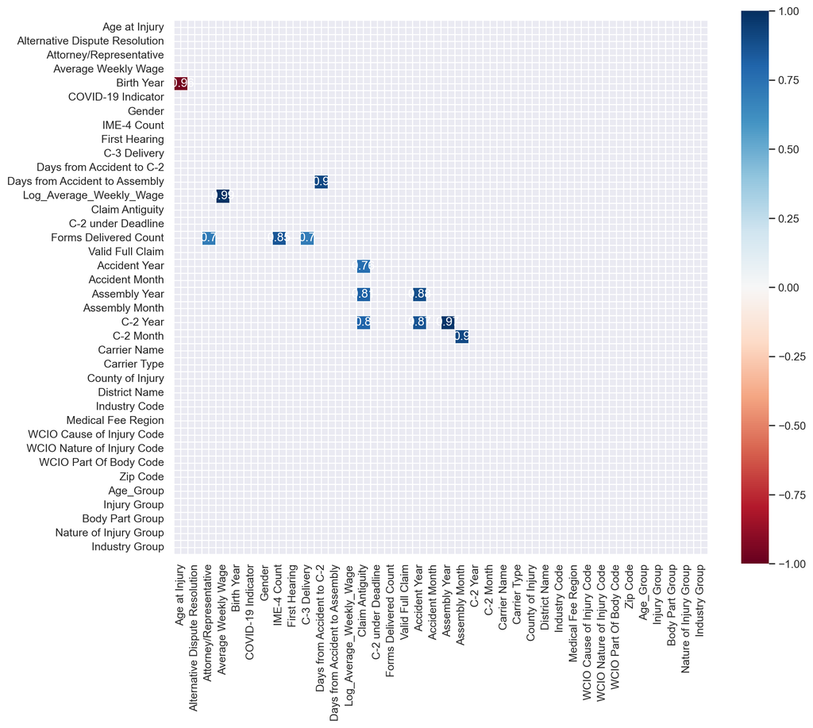

```python
cor_kendall = X_train_num_scaled.corr(method='kendall')
cor_heatmap(cor_kendall)
```

```python
def corr_pairs(corr, threshold):
    mask = np.tril(np.ones(corr.shape), k=-1).astype(bool)

    corr_lower = corr.where(mask)

    cor_pairs = corr_lower.unstack().dropna()
    cor_pairs = cor_pairs[(cor_pairs.abs() > threshold)]


    for pair, value in cor_pairs.items():
        feature_count_pair1 = len(corr[(corr[pair[0]].abs() > 0.2) & (corr[pair[0]].abs() < threshold)])
        feature_count_pair2 = len(corr[(corr[pair[1]].abs() > 0.2) & (corr[pair[1]].abs() < threshold)])

        print(f'{pair[0]} | significantly correlated with more {feature_count_pair1} features | or | {pair[1]} | significantly correlated with more {feature_count_pair2} features | {value:.2f}')
```

#### **If we define a treshold for redundancy of |0.80|:**

**`Kendall's correlation`:**

```python
corr_pairs(cor_kendall, threshold=0.8)
```

```
Age at Injury | significantly correlated with more 1 features | or | Birth Year | significantly correlated with more 1 features | -0.96
Average Weekly Wage | significantly correlated with more 5 features | or | Log_Average_Weekly_Wage | significantly correlated with more 5 features | 0.99
IME-4 Count | significantly correlated with more 6 features | or | Forms Delivered Count | significantly correlated with more 6 features | 0.85
Days from Accident to C-2 | significantly correlated with more 2 features | or | Days from Accident to Assembly | significantly correlated with more 2 features | 0.90
Claim Antiguity | significantly correlated with more 5 features | or | Assembly Year | significantly correlated with more 0 features | 0.81
Accident Year | significantly correlated with more 1 features | or | Assembly Year | significantly correlated with more 0 features | 0.88
Accident Year | significantly correlated with more 1 features | or | C-2 Year | significantly correlated with more 1 features | 0.87
Assembly Year | significantly correlated with more 0 features | or | C-2 Year | significantly correlated with more 1 features | 0.97
Assembly Month | significantly correlated with more 2 features | or | C-2 Month | significantly correlated with more 2 features | 0.90
```

```python
drop_kendall = ['Birth Year', 'Log_Average_Weekly_Wage', 'Assembly Month', 'Forms Delivered Count', 'Days from Accident to Assembly', 'Claim Antiguity', 'Accident Year']
```

**Feature selection for each method:**

```python
selected_features_kendall = X_train_num_scaled.columns.difference(drop_kendall).tolist()
print(f"Selected features: {selected_features_kendall}")
```

```
Selected features: ['Accident Month', 'Age at Injury', 'Age_Group', 'Alternative Dispute Resolution', 'Assembly Year', 'Attorney/Representative', 'Average Weekly Wage', 'Body Part Group', 'C-2 Month', 'C-2 Year', 'C-2 under Deadline', 'C-3 Delivery', 'COVID-19 Indicator', 'Carrier Name', 'Carrier Ty…
```

### `Step 2` Between output variable - Relevancy

Assessing the correlation between input feature and the output variable is meaningful to identify which features have stronger predictive power. Low correlation may indicate that a feature is less relevant, potentially being unimportant for our model- in such cases, the feature can be discarded.  
Removing such features helps to improve the model's interpretability and efficiency, by reducing the noise. However, we want remove solely based on this correlation, since we could be overlooking nonlinear relationships.  
**In this section, we are testing the input features for relevancy against the target variable.**

`Joining dataset with target, for assessment:`

```python
train_dataset = X_train_num_scaled.join(y_resampled_df, how='inner')  # Combine features and target
train_dataset.head(1)
```

|  | Age at Injury | Alternative Dispute Resolution | Attorney/Representative | Average Weekly Wage | Birth Year | COVID-19 Indicator | Gender | IME-4 Count | First Hearing | C-3 Delivery | ... | WCIO Cause of Injury Code | WCIO Nature of Injury Code | WCIO Part Of Body Code | Zip Code | Age_Group | Injury Group | Body Part Group | Nature of Injury Group | Industry Group | Claim Injury Type |
| --- | --- | --- | --- | --- | --- | --- | --- | --- | --- | --- | --- | --- | --- | --- | --- | --- | --- | --- | --- | --- | --- |
| 0 | 0.728814 | 0.0 | 1.0 | 0.0 | 0.448276 | 0.0 | 1.0 | 0.0 | 0.0 | 1.0 | ... | 0.96552 | 1.0 | 1.0 | 0.05064 | 0.861726 | 1.0 | 0.610547 | 1.0 | 0.936722 | 1 |

1 rows × 39 columns

**Defining a function that will plot a bar visualization, to compare the correlation between our input variables and our target variable:**

```python
def plot_target_correlation(correlation_matrix, method_name, target_column='Claim Injury Type'):

    # Extract correlations for the target variable and remove self-correlation
    target_cor = correlation_matrix[target_column].drop(target_column)

    # Sort correlations in descending order
    target_cor_sorted = target_cor.sort_values(ascending=False)

    # Plot the correlation with the target variable
    plt.figure(figsize=(10, 6))
    target_cor_sorted.plot(kind='bar', color='skyblue')
    plt.title(f'{method_name} Correlation with {target_column}')
    plt.xlabel('Features')
    plt.ylabel('Correlation Coefficient')
    plt.axhline(0, color='black', linewidth=0.5, linestyle='--')
    plt.show()
```

**`Correlation Bar Plot: Kendall`**

```python
kendall_matrix = train_dataset.corr(method ='kendall')
```

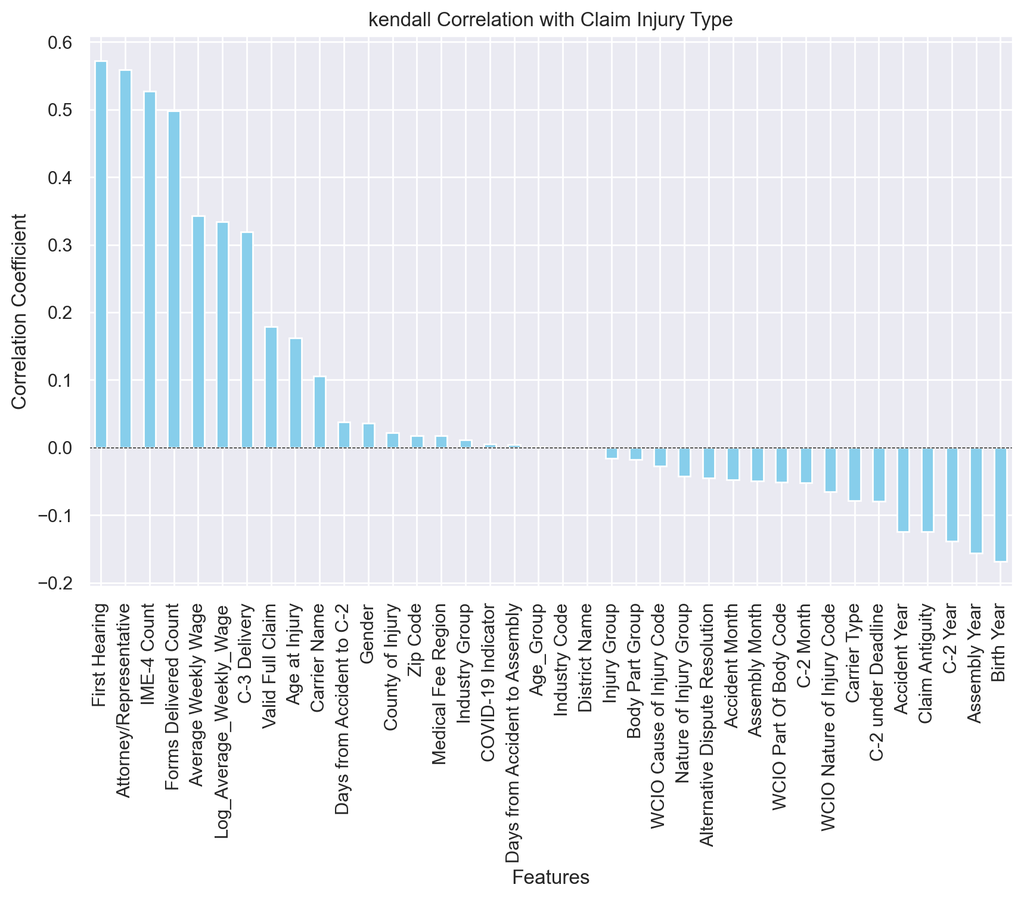

```python
plot_target_correlation(kendall_matrix, method_name='kendall')
```

```python
def corr_target(correlation_matrix, threshold, target_column='Claim Injury Type'):

    # Extract correlations for the target variable
    target_cor = correlation_matrix[target_column].drop(target_column)

    # Identify features with correlation below the threshold
    low_cor = target_cor[target_cor.abs() < threshold]

    return low_cor  # Return the low-correlation features as a Series
```

#### **If we define a treshold for relevancy of |0.15|:**

**`Kendall's correlation`:**

```python
drop_kendall_target = corr_target(kendall_matrix, threshold=0.15)
drop_kendall_target
```

```
Alternative Dispute Resolution   -0.044987
COVID-19 Indicator                0.005050
Gender                            0.035933
Days from Accident to C-2         0.037399
Days from Accident to Assembly    0.003905
Claim Antiguity                  -0.124551
C-2 under Deadline               -0.079569
Accident Year                    -0.124438
Accident Month                   -0.048185
Assembly Month                   -0.049559
C-2 Year                         -0.138890
C-2 Month                        -0.052079
Carrier Name                      0.105626
Carrier Type                     -0.078881
County of Injury                  0.021419
District Name                    -0.001642
Industry Code                    -0.000275
Medical Fee Region                0.017361
WCIO Cause of Injury Code        -0.027524
WCIO Nature of Injury Code       -0.065909
WCIO Part Of Body Code           -0.051741
Zip Code                          0.017600
Age_Group                         0.000932
Injury Group                     -0.016186
Body Part Group                  -0.017491
Nature of Injury Group           -0.043002
Industry Group                    0.011192
Name: Claim Injury Type, dtype: float64
```

```python
drop_kendall_target = drop_kendall_target.index.tolist()
```

```python
selected_target_kendall = X_train_num_scaled.columns.difference(drop_kendall_target).tolist()
print(f"Selected features: {selected_target_kendall}")
```

```
Selected features: ['Age at Injury', 'Assembly Year', 'Attorney/Representative', 'Average Weekly Wage', 'Birth Year', 'C-3 Delivery', 'First Hearing', 'Forms Delivered Count', 'IME-4 Count', 'Log_Average_Weekly_Wage', 'Valid Full Claim']
```

### 7.1.3. ANOVA

We use ANOVA, since it is applicable for both categorical and numerical input variables, and beacause the target variable's nature also complies with this method. This method doesn't assume data is normally distributed, making it a sound method for feature selection on this dataset.

**With that being said, we begin by joinining both subsets of data, to assess this feature selection methods on the entire dataset:**

```python
# Select the top K features using ANOVA F-test
selector = SelectKBest(f_classif, k=15)
X_selected = selector.fit_transform(X_train_num_scaled, y_resampled_df)

# Get the selected feature indices
selected_features_anova = X_train_num_scaled.columns[selector.get_support()].tolist()

print(f"Selected features: {selected_features_anova}")
```

```
Selected features: ['Age at Injury', 'Attorney/Representative', 'Birth Year', 'IME-4 Count', 'First Hearing', 'C-3 Delivery', 'Log_Average_Weekly_Wage', 'C-2 under Deadline', 'Forms Delivered Count', 'Valid Full Claim', 'Assembly Year', 'WCIO Nature of Injury Code', 'WCIO Part Of Body Code', 'Body P…
```

### 7.2. Wrapper Methods

```python
X_subset, _, y_subset, _ = train_test_split(
    X_train_num_scaled, y_resampled_df,
    test_size=0.9,  # Retain only 10% of the data
    stratify=y_resampled_df,  # Ensure class balance
    random_state=42
)
```

### 7.2.1. RFE - Base Model: Logistic Regression Classifier

We apply a Recursive Feature Elimination, that will recursively eliminate, one by one, the least important features, until it reaches the optimal number defined, or until the model stops improving.  
For this method, we start by using Logistic Regression as base model estimator:

```python
model = LogisticRegression()
```

```python
rfe = RFE(estimator = model, n_features_to_select = 18)
```

```python
X_rfe = rfe.fit_transform(X = X_subset, y = y_subset)
```

```python
rfe.support_
```

```
array([False,  True,  True, False,  True,  True, False,  True,  True,
        True,  True,  True,  True,  True, False,  True, False,  True,
       False,  True,  True,  True, False, False, False, False, False,
       False, False, False,  True, False, False, False, False,  True,
       False, False])
```

```python
rfe.ranking_
```

```
array([ 2,  1,  1, 21,  1,  1, 16,  1,  1,  1,  1,  1,  1,  1,  5,  1,  8,
        1, 20,  1,  1,  1, 12, 17, 18, 14, 10,  3, 15,  4,  1,  6, 19, 11,
       13,  1,  9,  7])
```

```python
selected_features_rfe = pd.Series(rfe.support_, index=X_train_num_scaled.columns)

selected_features_rfe = selected_features_rfe[selected_features_rfe == True].index.to_list()

print(f"Selected features: {selected_features_rfe}")
```

```
Selected features: ['Alternative Dispute Resolution', 'Attorney/Representative', 'Birth Year', 'COVID-19 Indicator', 'IME-4 Count', 'First Hearing', 'C-3 Delivery', 'Days from Accident to C-2', 'Days from Accident to Assembly', 'Log_Average_Weekly_Wage', 'Claim Antiguity', 'Forms Delivered Count', '…
```

### 7.2.2. RFE - Base Model: Support Vector Machines

Secondly, we use Support Vector Machines as our base estimator, a vector-based model that performs well on multi-classification tasks:

```python
model = SVC(kernel='linear')  # Support Vector Classifier with linear kernel
```

```python
rfe = RFE(estimator=model, n_features_to_select=18)  # Select 18 features
```

```python
X_rfe = rfe.fit_transform(X=X_subset, y=y_subset)
```

```python
rfe.support_
```

```
array([ True, False,  True, False,  True,  True, False,  True,  True,
        True,  True,  True,  True,  True, False,  True, False,  True,
       False,  True,  True,  True, False, False, False, False, False,
       False, False, False,  True, False, False, False, False,  True,
       False, False])
```

```python
rfe.ranking_
```

```
array([ 1,  9,  1, 21,  1,  1, 14,  1,  1,  1,  1,  1,  1,  1,  5,  1, 12,
        1, 20,  1,  1,  1,  8, 16, 15, 18, 11,  2, 17,  4,  1,  3, 13, 10,
       19,  1,  7,  6])
```

```python
selected_features_svm = pd.Series(rfe.support_, index=X_train_num_scaled.columns)

selected_features_svm = selected_features_svm[selected_features_svm == True].index.to_list()

print(f"Selected features: {selected_features_svm}")
```

```
Selected features: ['Age at Injury', 'Attorney/Representative', 'Birth Year', 'COVID-19 Indicator', 'IME-4 Count', 'First Hearing', 'C-3 Delivery', 'Days from Accident to C-2', 'Days from Accident to Assembly', 'Log_Average_Weekly_Wage', 'Claim Antiguity', 'Forms Delivered Count', 'Accident Year', '…
```

### 7.3. Embedded Methods

### 7.3.1. Lasso

Lasso, or L1 Regularization, applies a regression model and is a suitable feature selection method for our dataset, as it helps in both regularization and feature selection.  
Since our input variables are numerical, Lasso can perform effectively, allowing for automatic feature selection while improving model performance, by reducing overfitting.

```python
def plot_importance(coef,name):
    imp_coef = coef.sort_values()
    plt.figure(figsize=(8,10))
    imp_coef.plot(kind = "barh")
    plt.title("Feature importance using " + name + " Model")
    plt.show()
```

```python
reg = LassoCV()
```

```python
reg.fit(X_train_num_scaled, y_resampled_df)
```

```
LassoCV()
```

```python
coef = pd.Series(reg.coef_, index = X_train_num_scaled.columns)
coef.sort_values()
```

```
Assembly Year                    -3.695827
Days from Accident to Assembly   -1.505094
Assembly Month                   -1.503573
Birth Year                       -0.878942
C-3 Delivery                     -0.633671
WCIO Nature of Injury Code       -0.303293
WCIO Part Of Body Code           -0.290233
Body Part Group                  -0.226565
District Name                    -0.210119
County of Injury                 -0.139524
Accident Month                   -0.128367
Carrier Type                     -0.126723
WCIO Cause of Injury Code        -0.107725
C-2 under Deadline               -0.099469
C-2 Month                        -0.099411
Injury Group                     -0.031950
Zip Code                         -0.018017
C-2 Year                         -0.000000
Age at Injury                    -0.000000
Accident Year                     0.000000
Alternative Dispute Resolution   -0.000000
Average Weekly Wage               0.000000
IME-4 Count                      -0.000000
Nature of Injury Group           -0.000000
Days from Accident to C-2        -0.000000
Age_Group                         0.004537
Medical Fee Region                0.005067
COVID-19 Indicator                0.033170
Gender                            0.067553
Carrier Name                      0.162630
Valid Full Claim                  0.251680
Industry Group                    0.282610
Industry Code                     0.553753
Forms Delivered Count             0.890152
First Hearing                     1.055173
Attorney/Representative           1.154991
Log_Average_Weekly_Wage           2.379950
Claim Antiguity                   5.092844
dtype: float64
```

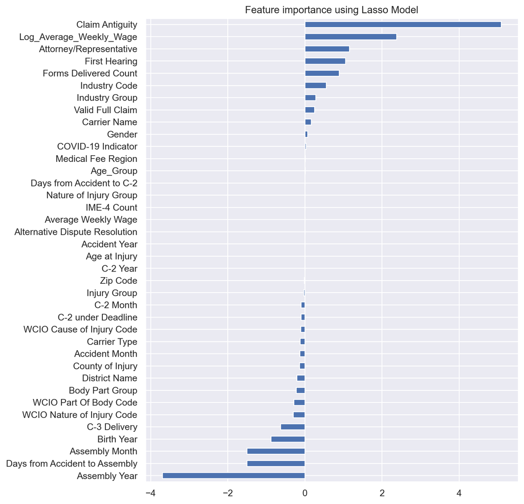

```python
plot_importance(coef,'Lasso')
```

```python
threshold = 0.01  # Define the threshold for LASSO coefficients

# Print how many variables are kept or eliminated
print("Lasso picked " + str(sum(abs(coef) > threshold)) + " variables and eliminated the other " +
      str(sum(abs(coef) <= threshold)) + " variables")

# Get the selected features based on the threshold
selected_features_lasso = coef[abs(coef) > threshold].index.to_list()

print(f"Selected features: {selected_features_lasso}")
```

```
Lasso picked 28 variables and eliminated the other 10 variables
Selected features: ['Attorney/Representative', 'Birth Year', 'COVID-19 Indicator', 'Gender', 'First Hearing', 'C-3 Delivery', 'Days from Accident to Assembly', 'Log_Average_Weekly_Wage', 'Claim Antiguity', 'C-2 under Deadline', 'Forms Delivered Count', 'Valid Full Claim', 'Accident Month', 'Assembly…
```

### 7.3.2. Random Forest Classifier

Random Forest Classifier is a method chosen, since we will also deploy this model, and it measures the level of impurity (gini and entropy criteria) that each features is responsible for reducing to the model.

```python
model = RandomForestClassifier(n_estimators=100, random_state=42)
model.fit(X_train_num_scaled, y_resampled_df)

mean_importance = model.feature_importances_.mean()
threshold_value = mean_importance

selector = SelectFromModel(model, threshold=threshold_value, prefit=True)
selected_features = X_train_num_scaled.columns[(selector.get_support())]

selected_features_rf = selected_features.to_list()

print("Selected Features:", selected_features_rf)
```

```
Selected Features: ['Age at Injury', 'Attorney/Representative', 'Average Weekly Wage', 'Birth Year', 'IME-4 Count', 'First Hearing', 'Days from Accident to C-2', 'Days from Accident to Assembly', 'Log_Average_Weekly_Wage', 'Claim Antiguity', 'Forms Delivered Count', 'Carrier Name', 'County of Injury…
```

### 7.4. Standalone Methods

### 7.4.1. Decision Trees

This supervised learning algorithm, just like Random Forest, selects features by measuring the level of impurity that each one reduced in the model.

```python
model = DecisionTreeClassifier(random_state=42)
model.fit(X_train_num_scaled, y_resampled_df)

feature_importances = pd.Series(model.feature_importances_, index=X_train_num_scaled.columns)

mean_importance = feature_importances.mean()
selected_features_dt = feature_importances[feature_importances > mean_importance].index.to_list()

print(f"Selected features: {selected_features_dt}")
```

```
Selected features: ['Age at Injury', 'Attorney/Representative', 'Average Weekly Wage', 'Birth Year', 'Days from Accident to C-2', 'Days from Accident to Assembly', 'Log_Average_Weekly_Wage', 'Claim Antiguity', 'Forms Delivered Count', 'Carrier Name', 'County of Injury', 'Industry Code', 'WCIO Cause …
```

## 8. Final Insights

### 8.1. Final feature selection

```python
data = {'Feature': X_train_num_scaled.columns}

data['Variance'] = ['Keep' if feature in selected_features_variance else 'Not Tested' if feature not in X_train_num_scaled.columns else 'Discard' for feature in X_train_num_scaled.columns]
data['Kendall'] = ['Keep' if feature in selected_features_kendall else 'Not Tested' if feature not in X_train_num_scaled.columns else 'Discard' for feature in X_train_num_scaled.columns]
data['Target Kendall'] = ['Keep' if feature in selected_target_kendall else 'Not Tested' if feature not in X_train_num_scaled.columns else 'Discard' for feature in X_train_num_scaled.columns]
data['ANOVA'] = ['Keep' if feature in selected_features_anova else 'Not Tested' if feature not in X_train_num_scaled.columns else 'Discard' for feature in X_train_num_scaled.columns]
data['LASSO'] = ['Keep' if feature in selected_features_lasso else 'Discard' for feature in X_train_num_scaled.columns]
#data['RFE LR'] = ['Keep' if feature in selected_features_rfe else 'Discard' for feature in X_train_num_scaled.columns]
#data['RFE SVM'] = ['Keep' if feature in selected_features_svm else 'Discard' for feature in X_train_num_scaled.columns]
data['DT'] = ['Keep' if feature in selected_features_dt else 'Discard' for feature in X_train_num_scaled.columns]
data['RandomForest'] = ['Keep' if feature in selected_features_rf else 'Discard' for feature in X_train_num_scaled.columns]


fs_table = pd.DataFrame(data)
fs_table['Result'] = fs_table.iloc[:, 1:].apply(
    lambda x: 'Selected' if (list(x[x != 'Not Tested']).count('Keep') - 1) > list(x[x != 'Not Tested']).count('Discard')
    else 'Not Selected',
    axis=1)

feature_selection = fs_table[fs_table['Result'] == 'Selected']['Feature'].tolist()

def color_cells(val):
    if val == 'Keep':
        return 'background-color: lightgreen'
    elif val == 'Discard':
        return 'background-color: lightcoral'
    elif val == 'Selected':
        return 'background-color: lightgreen; border: 2px solid darkgreen; font-weight: bold'
    elif val == 'Not Selected':
        return 'background-color: lightcoral; border: 2px solid darkred; font-weight: bold'
    else:
        return ''

styled_fs_table = fs_table.style.applymap(color_cells, subset=fs_table.columns[1:])

styled_fs_table
```

|  | Feature | Variance | Kendall | Target Kendall | ANOVA | LASSO | DT | RandomForest | Result |
| --- | --- | --- | --- | --- | --- | --- | --- | --- | --- |
| 0 | Age at Injury | Keep | Keep | Keep | Keep | Discard | Keep | Keep | Selected |
| 1 | Alternative Dispute Resolution | Discard | Keep | Discard | Discard | Discard | Discard | Discard | Not Selected |
| 2 | Attorney/Representative | Keep | Keep | Keep | Keep | Keep | Keep | Keep | Selected |
| 3 | Average Weekly Wage | Discard | Keep | Keep | Discard | Discard | Keep | Keep | Not Selected |
| 4 | Birth Year | Discard | Discard | Keep | Keep | Keep | Keep | Keep | Selected |
| 5 | COVID-19 Indicator | Discard | Keep | Discard | Discard | Keep | Discard | Discard | Not Selected |
| 6 | Gender | Keep | Keep | Discard | Discard | Keep | Discard | Discard | Not Selected |
| 7 | IME-4 Count | Discard | Keep | Keep | Keep | Discard | Discard | Keep | Not Selected |
| 8 | First Hearing | Keep | Keep | Keep | Keep | Keep | Discard | Keep | Selected |
| 9 | C-3 Delivery | Keep | Keep | Keep | Keep | Keep | Discard | Discard | Selected |
| 10 | Days from Accident to C-2 | Discard | Keep | Discard | Discard | Discard | Keep | Keep | Not Selected |
| 11 | Days from Accident to Assembly | Discard | Discard | Discard | Discard | Keep | Keep | Keep | Not Selected |
| 12 | Log_Average_Weekly_Wage | Discard | Discard | Keep | Keep | Keep | Keep | Keep | Selected |
| 13 | Claim Antiguity | Keep | Discard | Discard | Discard | Keep | Keep | Keep | Not Selected |
| 14 | C-2 under Deadline | Keep | Keep | Discard | Keep | Keep | Discard | Discard | Not Selected |
| 15 | Forms Delivered Count | Discard | Discard | Keep | Keep | Keep | Keep | Keep | Selected |
| 16 | Valid Full Claim | Keep | Keep | Keep | Keep | Keep | Discard | Discard | Selected |
| 17 | Accident Year | Discard | Discard | Discard | Discard | Discard | Discard | Discard | Not Selected |
| 18 | Accident Month | Keep | Keep | Discard | Discard | Keep | Discard | Discard | Not Selected |
| 19 | Assembly Year | Keep | Keep | Keep | Keep | Keep | Discard | Discard | Selected |
| 20 | Assembly Month | Keep | Discard | Discard | Discard | Keep | Discard | Discard | Not Selected |
| 21 | C-2 Year | Discard | Keep | Discard | Discard | Discard | Discard | Discard | Not Selected |
| 22 | C-2 Month | Keep | Keep | Discard | Discard | Keep | Discard | Discard | Not Selected |
| 23 | Carrier Name | Keep | Keep | Discard | Discard | Keep | Keep | Keep | Selected |
| 24 | Carrier Type | Keep | Keep | Discard | Discard | Keep | Discard | Discard | Not Selected |
| 25 | County of Injury | Keep | Keep | Discard | Discard | Keep | Keep | Keep | Selected |
| 26 | District Name | Keep | Keep | Discard | Discard | Keep | Discard | Discard | Not Selected |
| 27 | Industry Code | Keep | Keep | Discard | Discard | Keep | Keep | Keep | Selected |
| 28 | Medical Fee Region | Keep | Keep | Discard | Discard | Discard | Discard | Discard | Not Selected |
| 29 | WCIO Cause of Injury Code | Keep | Keep | Discard | Discard | Keep | Keep | Keep | Selected |
| 30 | WCIO Nature of Injury Code | Keep | Keep | Discard | Keep | Keep | Keep | Keep | Selected |
| 31 | WCIO Part Of Body Code | Keep | Keep | Discard | Keep | Keep | Keep | Keep | Selected |
| 32 | Zip Code | Discard | Keep | Discard | Discard | Keep | Keep | Keep | Not Selected |
| 33 | Age_Group | Keep | Keep | Discard | Discard | Discard | Discard | Discard | Not Selected |
| 34 | Injury Group | Keep | Keep | Discard | Discard | Keep | Discard | Discard | Not Selected |
| 35 | Body Part Group | Keep | Keep | Discard | Keep | Keep | Keep | Keep | Selected |
| 36 | Nature of Injury Group | Keep | Keep | Discard | Keep | Discard | Discard | Discard | Not Selected |
| 37 | Industry Group | Keep | Keep | Discard | Discard | Keep | Keep | Discard | Not Selected |

```python
feature_selection
```

```
['Age at Injury',
 'Attorney/Representative',
 'Birth Year',
 'First Hearing',
 'C-3 Delivery',
 'Log_Average_Weekly_Wage',
 'Forms Delivered Count',
 'Valid Full Claim',
 'Assembly Year',
 'Carrier Name',
 'County of Injury',
 'Industry Code',
 'WCIO Cause of Injury Code',
 'WCIO Nature of Injury Code',
 'WCIO Part Of Body Code',
 'Body Part Group']
```

```python
len(feature_selection)
```

```
16
```

```python
X_train_fs = X_train_num_scaled[feature_selection]
X_val_fs = X_val_num_scaled[feature_selection]
X_test_fs = X_test_num_scaled[feature_selection]
```

### 8.2. Export Datasets and variables for following notebook

```python
X_train_fs.to_csv('X_train_nb2.csv', index=True)
X_val_fs.to_csv('X_val_nb2.csv', index=True)
X_test_fs.to_csv('X_test_nb2.csv', index=True)

print("The datasets have been exported to csv.")
```

```
The datasets have been exported to csv.
```

```python
y_resampled_df.to_csv("y_train_nb2.csv", index=True)
print("The datasets have been exported to csv.")
```

```
The datasets have been exported to csv.
```